# RQ2: Artificially Attritioned Datasets

## Percentiles of effects

```r
bootstrap_summary_df_ace %>%
  filter(group == "Difference", par %in% c("a", "c", "e")) %>%
  select(y) %>%
  summarise(
    n_tests = dplyr::n(),
    mean    = mean(abs(y)),
    p50     = quantile(abs(y), .50),
    p90     = quantile(abs(y), .90),
    p95     = quantile(abs(y), .95),
    max     = max(abs(y))
  ) %>%
  gt() %>%
  cols_label(
    n_tests = "Tests (total)",
    mean    = "Mean",
    p50     = "Median",
    p90     = "90th",
    p95     = "95th",
    max     = "Max"
  ) %>%
  fmt_number(columns = c(mean, p50, p90, p95, max), decimals = 3) %>%
  tab_spanner(
    label = md("|ACE Difference| Percentiles"),
    columns = c(p50, p90, p95, max)
  ) %>%
  tab_style(
    style = cell_text(size = px(11)),
    locations = list(cells_body(), cells_column_labels(), cells_column_spanners())
  ) %>%
  tab_footnote(
    footnote = md("<em>Note.</em> Percentiles of |ACE<sub>attritioned</sub> − ACE<sub>original</sub>| across all variables, timepoints, and ACE components (A, C, E)."),
    placement = "right"
  )
```

| Tests (total) | Mean | \|ACE Difference\| Percentiles Median | \|ACE Difference\| Percentiles 90th | \|ACE Difference\| Percentiles 95th | \|ACE Difference\| Percentiles Max |
| --- | --- | --- | --- | --- | --- |
| 486 | 0.033 | 0.020 | 0.078 | 0.109 | 0.224 |

*Note.* Percentiles of |ACE<sub>attritioned</sub> − ACE<sub>original</sub>| across all variables, timepoints, and ACE components (A, C, E).

## Directional Consistency Across Variables

```r
# For each ACE component × variable, how many of the sex × timepoint
# combinations show a positive vs negative change, and how many are significant?
bootstrap_summary_df_ace %>%
  filter(group == "Difference", par %in% c("a", "c", "e")) %>%
  mutate(
    par        = toupper(par),
    name_clean = rq2y_labels_short[match(name, rq2y)]
  ) %>%
  group_by(par, name_clean) %>%
  summarise(
    n         = dplyr::n(),
    n_pos     = sum(y > 0),
    n_neg     = sum(y < 0),
    n_sig_pos = sum(pval < 0.05 & y > 0),
    n_sig_neg = sum(pval < 0.05 & y < 0),
    mean_diff = mean(y),
    .groups   = "drop"
  ) %>%
  arrange(par, name_clean) %>%
  gt(groupname_col = "par", rowname_col = "name_clean") %>%
  cols_label(
    n         = "N",
    n_pos     = md("N &uarr;"),
    n_neg     = md("N &darr;"),
    n_sig_pos = md("N sig &uarr;"),
    n_sig_neg = md("N sig &darr;"),
    mean_diff = "Mean diff"
  ) %>%
  fmt_number(columns = mean_diff, decimals = 3) %>%
  tab_style(
    style = cell_text(size = px(10)),
    locations = list(
      cells_body(), cells_stub(), cells_row_groups(), cells_column_labels()
    )
  ) %>%
  tab_style(
    style = cell_fill(color = "#d5e8d4"),
    locations = cells_body(columns = n_pos, rows = n_pos == n)
  ) %>%
  tab_style(
    style = cell_fill(color = "#f8cecc"),
    locations = cells_body(columns = n_neg, rows = n_neg == n)
  ) %>%
  tab_footnote(
    footnote = md("<em>Note.</em> N = number of sex × timepoint combinations. N &uarr; / N &darr; = number with positive/negative change (Attritioned − Original). N sig = number with p<sub>unadj</sub> < 0.05. Cells highlighted when all combinations agree in direction."),
    placement = "right"
  )
```

|  | N | N ↑ | N ↓ | N sig ↑ | N sig ↓ | Mean diff |
| --- | --- | --- | --- | --- | --- | --- |
| A |  |  |  |  |  |  |
| Conduct problems | 18 | 6 | 12 | 0 | 0 | −0.024 |
| Emotional problems | 18 | 7 | 11 | 0 | 0 | −0.020 |
| Grammar | 18 | 7 | 11 | 0 | 1 | −0.032 |
| Hyperactivity | 18 | 11 | 7 | 1 | 0 | 0.007 |
| Parent-admin cognition | 18 | 5 | 13 | 0 | 0 | −0.008 |
| Parent-report cognition | 18 | 3 | 15 | 0 | 0 | −0.034 |
| Peer problems | 18 | 6 | 12 | 0 | 2 | −0.039 |
| Prosocial behavior | 18 | 6 | 12 | 0 | 0 | −0.025 |
| Vocabulary | 18 | 7 | 11 | 0 | 1 | 0.000 |
| C |  |  |  |  |  |  |
| Conduct problems | 18 | 15 | 3 | 0 | 0 | 0.031 |
| Emotional problems | 18 | 13 | 5 | 0 | 0 | 0.029 |
| Grammar | 18 | 12 | 6 | 3 | 0 | 0.038 |
| Hyperactivity | 18 | 16 | 2 | 0 | 0 | 0.005 |
| Parent-admin cognition | 18 | 10 | 8 | 0 | 0 | −0.006 |
| Parent-report cognition | 18 | 15 | 3 | 0 | 0 | 0.048 |
| Peer problems | 18 | 16 | 2 | 0 | 0 | 0.015 |
| Prosocial behavior | 18 | 13 | 5 | 0 | 0 | 0.027 |
| Vocabulary | 18 | 11 | 7 | 2 | 0 | 0.011 |
| E |  |  |  |  |  |  |
| Conduct problems | 18 | 11 | 7 | 0 | 1 | −0.007 |
| Emotional problems | 18 | 10 | 8 | 0 | 0 | −0.009 |
| Grammar | 18 | 6 | 12 | 0 | 1 | −0.006 |
| Hyperactivity | 18 | 7 | 11 | 0 | 1 | −0.011 |
| Parent-admin cognition | 18 | 14 | 4 | 3 | 0 | 0.014 |
| Parent-report cognition | 18 | 4 | 14 | 0 | 2 | −0.014 |
| Peer problems | 18 | 10 | 8 | 2 | 0 | 0.024 |
| Prosocial behavior | 18 | 6 | 12 | 0 | 0 | −0.002 |
| Vocabulary | 18 | 3 | 15 | 0 | 7 | −0.011 |

*Note.* N = number of sex × timepoint combinations. N ↑ / N ↓ = number with positive/negative change (Attritioned − Original). N sig = number with p<sub>unadj</sub> < 0.05. Cells highlighted when all combinations agree in direction.

## Forest Plot of ACE Changes

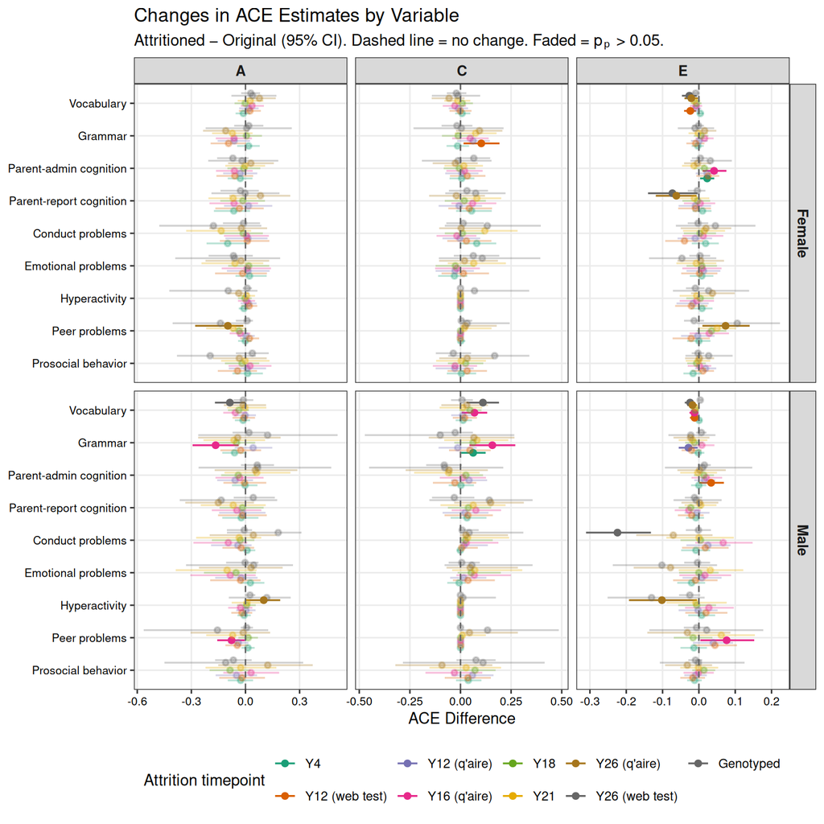

```r
bootstrap_summary_df_ace %>%
  filter(group == "Difference", par %in% c("a", "c", "e")) %>%
  mutate(
    par           = toupper(par),
    sex           = str_to_title(sex),
    name_clean    = rq2y_labels_short[match(name, rq2y)],
    name_clean    = factor(name_clean, levels = rev(rq2y_labels_short)),
    dataset_label = factor(dataset_label, levels = rq1y_twin_labels_clean_extrashort),
    significant   = pval < 0.05
  ) %>%
  ggplot(aes(
    x     = y,
    xmin  = ymin,
    xmax  = ymax,
    y     = name_clean,
    color = dataset_label,
    alpha = significant
  )) +
  geom_pointrange(position = position_dodge(width = 0.7), size = 0.3, linewidth = 0.6) +
  geom_vline(xintercept = 0, linetype = "dashed", color = "grey40", linewidth = 0.5) +
  facet_grid(sex ~ par, scales = "free_x") +
  scale_color_manual(
    values = c(RColorBrewer::brewer.pal(8, "Dark2"), "#666666"),
    name = "Attrition timepoint"
  ) +
  scale_alpha_manual(values = c("TRUE" = 1, "FALSE" = 0.3), guide = "none") +
  labs(
    title    = "Changes in ACE Estimates by Variable",
    subtitle = "Attritioned \u2212 Original (95% CI). Dashed line = no change. Faded = p\u209a > 0.05.",
    x        = "ACE Difference",
    y        = NULL
  ) +
  theme_bw() +
  theme(
    strip.text       = element_text(face = "bold", size = 10),
    axis.text        = element_text(color = "black", size = 8),
    legend.position  = "bottom",
    panel.grid.minor = element_blank()
  )
```

```r
save_plot("2_rq2_ace_forest", width = 8, height = 7)
```

View full-size plot

## ACE Stacked Bar Plot

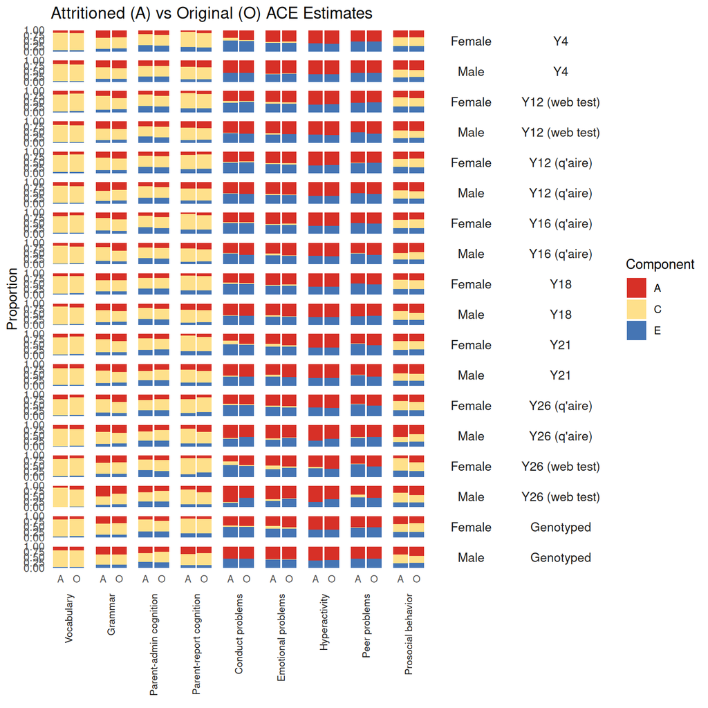

```r
bootstrap_summary_df_ace %>%
  # filter(dataset_label == "Y4") %>%
  filter(par %in% c("a","c","e")) %>%
  filter(group != "Difference") %>%
  mutate(
    dataset_label = factor(dataset_label, levels = rq1y_twin_labels_clean_extrashort),
    name = factor(rq2y_labels_short[match(name, rq2y)], levels = rq2y_labels_short),
    group = ifelse(group == "Attritioned", "A", "O"),
    group = factor(group, levels = c("A", "O")),
    sex = str_to_title(sex),
    par = toupper(par)
  ) %>%
  ggplot(aes(x = group, y = y, fill = par)) +
  geom_col(position = "stack", alpha = 1) +
  facet_grid(dataset_label + sex ~ name, switch = "x") +
  theme_minimal() +
  theme(
    axis.text.x = element_text(angle = 0, hjust = .5, size = 8),
    strip.text = element_text(size = 8),
    strip.text.x = element_text(angle = 90, hjust = 1, vjust = .5, size = 8),
    strip.text.y = element_text(angle = 0, size = 10),
    strip.placement = "outside",
    panel.grid = element_blank(),
    plot.tag = element_text(hjust = 0, vjust = 0, size = 24, face = "bold"),
    plot.tag.position = "topleft"
  ) +
  labs(
    title = "Attritioned (A) vs Original (O) ACE Estimates",
    y     = "Proportion",
    x     = NULL,
    fill  = "Component"
  ) +
  scale_fill_manual(values = c("A" = "#d73027", "C" = "#fee08b", "E" = "#4575b4")) +
  coord_cartesian(ylim = c(0, 1))
```

[figure not shown]

```r
save_plot("2_rq2_ace_comparison", width = 7, height = 15, trim = TRUE)

# Create a looped version where we have plots for each timepoint

ace_plots = lapply(rq1y_twin_labels_clean_extrashort, function(timepoint) {

  bootstrap_summary_df_ace %>%
  filter(dataset_label == timepoint) %>%
  filter(par %in% c("a","c","e")) %>%
  filter(group != "Difference") %>%
  mutate(
    name = factor(rq2y_labels_short[match(name, rq2y)], levels = rq2y_labels_short),
    group = ifelse(group == "Attritioned", "A", "O"),
    group = factor(group, levels = c("A", "O")),
    sex = str_to_title(sex),
    par = toupper(par)
  ) %>%
  ggplot(aes(x = group, y = y, fill = par)) +
  geom_col(position = "stack", alpha = 1) +
  facet_grid(sex ~ name, switch = if(timepoint == "Y4") "both" else "x") +
  theme_minimal() +
  theme(
    axis.text.x = element_text(angle = 0, hjust = .5, size = 8),
    axis.text.y = if(timepoint != "Y4") element_blank(),
    strip.text = element_text(size = 8),
    strip.text.x = element_text(angle = 90, hjust = 1, vjust = .5, size = 8),
    strip.text.y = element_blank(),
    strip.text.y.left = if(timepoint == "Y4") element_text(angle = 0, size = 10) else element_blank(),
    strip.placement = "outside",
    panel.grid = element_blank()
  ) +
  labs(
    title = timepoint,
    y     = if(timepoint == "Y4") "Proportion" else NULL,
    x     = NULL,
    fill  = "Component"
  ) +
  scale_fill_manual(values = c("A" = "#d73027", "C" = "#fee08b", "E" = "#4575b4")) +
  coord_cartesian(ylim = c(0, 1))
})

names(ace_plots) = rq1y_twin_labels_clean_extrashort

# Arrange all plots vertically with shared legend
patchwork::wrap_plots(ace_plots, nrow = 1) +
  patchwork::plot_layout(guides = "collect") +
  patchwork::plot_annotation(
    title = "Attritioned (A) vs Original (O) ACE Estimates by Timepoint"
  )
```

```r
save_plot("2_rq2_ace_comparison_by_timepoint", width = 21, height = 9, trim = FALSE)
```

📊 View plot 1 📊 View plot 2

# Supplementary Analyses

## Effect of attritioning on sample sizes

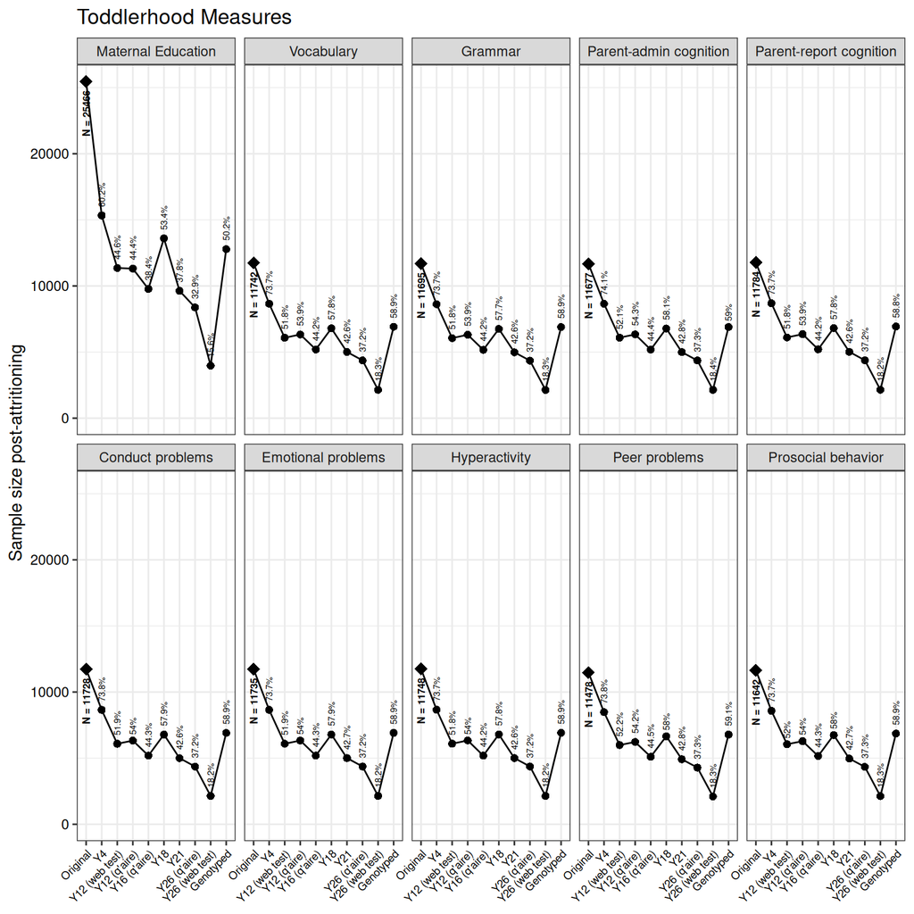

```r
response_statistics = df %>%
  select(randomtwinid, all_of(rq2y), all_of(rq1y_twin1)) %>%
  mutate(all1 = 1) %>%
  pivot_longer(cols = all_of(rq2y), names_to = "variable", values_to = "score") %>%
  pivot_longer(cols = all_of(c("all1", rq1y_twin1)), names_to = "timepoint", values_to = "participation_indicator") %>%
  filter(!is.na(score)) %>%
  filter(participation_indicator ==1)  %>%
  group_by(variable, timepoint) %>%
  summarise(
    n = dplyr::n(),
    .groups = "drop"
  ) %>%
  group_by(variable) %>%
  mutate(
    max = base::max(n),
    percent = n/max
  )

response_statistics %>%
  mutate(
    variable = rq2y_labels_short[match(variable, rq2y)],
    variable = factor(variable, levels = rq2y_labels_short),
    timepoint = rq1y_twin_labels_clean_extrashort[match(timepoint, rq1y_twin1)],
    timepoint = ifelse(is.na(timepoint), "Original", timepoint),
    timepoint = factor(timepoint, levels = c("Original", rq1y_twin_labels_clean_extrashort)),
    original  = factor(ifelse(timepoint == "Original", "Original", "Attritioned"))
  ) %>%
  ggplot(aes(x = timepoint, y = n, group = variable)) +
  geom_line() +
  geom_point(aes(shape = original, size = original)) +
  geom_text(
    data = ~ filter(.x, timepoint == "Original"),
    aes(label = paste0("N = ", as.character(n))),
    vjust = .5, hjust = 1.2, size = 2.2, angle = 90, fontface = "bold"
  ) +
  geom_text(
    data = ~ filter(.x, timepoint != "Original"),
    aes(label = paste0(round(percent * 100, digits = 1), "%")),
    vjust = .5, hjust = -.35, size = 1.9, angle = 90
  ) +
  scale_shape_manual(values = c("Original" = 18, "Attritioned" = 16)) +
  scale_size_manual(values = c("Original" = 3.5, "Attritioned" = 2)) +
  scale_y_continuous(limits = c(0, NA)) +
  labs(
    y = "Sample size post-attritioning",
    x = NULL
  ) +
  facet_wrap(~variable, nrow = 2) +
  theme_bw() +
  theme(
    axis.text   = element_text(color = "black"),
    axis.text.x = element_text(angle = 45, vjust = 1, hjust = 1, size = 7),
    legend.position = "none"
  ) +
  labs(
    title = "Toddlerhood Measures"
  )
```

```r
save_plot("2_attrition_numbers", width = 7.3, height = 4.3)
```

📊 View Full Resolution Attrition Numbers Plot (PNG)

### Sample Size Table

```r
response_statistics %>%
  mutate(
    variable = rq2y_labels_short[match(variable, rq2y)],
    variable = factor(variable, levels = rq2y_labels_short),
    timepoint = rq1y_twin_labels_clean_extrashort[match(timepoint, rq1y_twin1)],
    timepoint = ifelse(is.na(timepoint), "Original", timepoint),
    # Combine n and percent into formatted string
    n_pct = paste0(format(n, big.mark = ","), " (", sprintf("%.1f%%", percent * 100), ")")
  ) %>%
  select(variable, timepoint, n_pct) %>%
  pivot_wider(names_from = timepoint, values_from = n_pct) %>%
  arrange(variable) %>%
  gt() %>%
  cols_label(
    variable = "Variable"
  ) %>%
  tab_spanner(
    label = "Sample Size (% of Original) by Attrition Timepoint",
    columns = -variable
  ) %>%
  tab_style(
    style = cell_text(size = px(10)),
    locations = list(
      cells_body(),
      cells_stub(),
      cells_row_groups(),
      cells_column_labels(),
      cells_column_spanners(),
      cells_footnotes()
    )
  ) %>%
  tab_footnote(
    footnote = "Original = full sample before any attrition. Other columns show sample sizes (and percentage of original) after removing participants who did not take part at that timepoint.",
    placement = "right"
  ) %>%
  cols_move_to_start(columns = c(variable, Original))
```

| Sample Size (% of Original) by Attrition Timepoint Original | Sample Size (% of Original) by Attrition Timepoint Y4 | Sample Size (% of Original) by Attrition Timepoint Genotyped | Sample Size (% of Original) by Attrition Timepoint Y12 (q'aire) | Sample Size (% of Original) by Attrition Timepoint Y12 (web test) | Sample Size (% of Original) by Attrition Timepoint Y16 (q'aire) | Sample Size (% of Original) by Attrition Timepoint Y18 | Sample Size (% of Original) by Attrition Timepoint Y21 | Sample Size (% of Original) by Attrition Timepoint Y26 (web test) | Sample Size (% of Original) by Attrition Timepoint Y26 (q'aire) |
| --- | --- | --- | --- | --- | --- | --- | --- | --- | --- |
| Maternal Education |  |  |  |  |  |  |  |  |  |
| 25,466 (100.0%) | 15,334 (60.2%) | 12,783 (50.2%) | 11,310 (44.4%) | 11,359 (44.6%) | 9,772 (38.4%) | 13,600 (53.4%) | 9,631 (37.8%) | 3,970 (15.6%) | 8,375 (32.9%) |
| Vocabulary |  |  |  |  |  |  |  |  |  |
| 11,742 (100.0%) | 8,654 (73.7%) | 6,913 (58.9%) | 6,330 (53.9%) | 6,081 (51.8%) | 5,194 (44.2%) | 6,792 (57.8%) | 5,007 (42.6%) | 2,143 (18.3%) | 4,373 (37.2%) |
| Grammar |  |  |  |  |  |  |  |  |  |
| 11,695 (100.0%) | 8,620 (73.7%) | 6,891 (58.9%) | 6,309 (53.9%) | 6,055 (51.8%) | 5,167 (44.2%) | 6,749 (57.7%) | 4,983 (42.6%) | 2,136 (18.3%) | 4,352 (37.2%) |
| Parent-admin cognition |  |  |  |  |  |  |  |  |  |
| 11,677 (100.0%) | 8,654 (74.1%) | 6,893 (59.0%) | 6,337 (54.3%) | 6,088 (52.1%) | 5,183 (44.4%) | 6,782 (58.1%) | 4,994 (42.8%) | 2,145 (18.4%) | 4,361 (37.3%) |
| Parent-report cognition |  |  |  |  |  |  |  |  |  |
| 11,784 (100.0%) | 8,686 (73.7%) | 6,933 (58.8%) | 6,356 (53.9%) | 6,104 (51.8%) | 5,208 (44.2%) | 6,816 (57.8%) | 5,018 (42.6%) | 2,145 (18.2%) | 4,379 (37.2%) |
| Conduct problems |  |  |  |  |  |  |  |  |  |
| 11,728 (100.0%) | 8,650 (73.8%) | 6,907 (58.9%) | 6,330 (54.0%) | 6,086 (51.9%) | 5,191 (44.3%) | 6,787 (57.9%) | 5,001 (42.6%) | 2,137 (18.2%) | 4,364 (37.2%) |
| Emotional problems |  |  |  |  |  |  |  |  |  |
| 11,735 (100.0%) | 8,651 (73.7%) | 6,911 (58.9%) | 6,333 (54.0%) | 6,088 (51.9%) | 5,193 (44.3%) | 6,790 (57.9%) | 5,005 (42.7%) | 2,141 (18.2%) | 4,370 (37.2%) |
| Hyperactivity |  |  |  |  |  |  |  |  |  |
| 11,748 (100.0%) | 8,662 (73.7%) | 6,918 (58.9%) | 6,339 (54.0%) | 6,091 (51.8%) | 5,192 (44.2%) | 6,796 (57.8%) | 5,003 (42.6%) | 2,141 (18.2%) | 4,370 (37.2%) |
| Peer problems |  |  |  |  |  |  |  |  |  |
| 11,478 (100.0%) | 8,474 (73.8%) | 6,784 (59.1%) | 6,223 (54.2%) | 5,992 (52.2%) | 5,103 (44.5%) | 6,656 (58.0%) | 4,917 (42.8%) | 2,101 (18.3%) | 4,283 (37.3%) |
| Prosocial behavior |  |  |  |  |  |  |  |  |  |
| 11,642 (100.0%) | 8,577 (73.7%) | 6,859 (58.9%) | 6,286 (54.0%) | 6,049 (52.0%) | 5,160 (44.3%) | 6,749 (58.0%) | 4,968 (42.7%) | 2,126 (18.3%) | 4,340 (37.3%) |

Original = full sample before any attrition. Other columns show sample sizes (and percentage of original) after removing participants who did not take part at that timepoint.

## How predictive are our variables of later attrition?

### Correlations

```r
sapply(rq2y, function(x)
  sapply(rq1y_twin1, function(y)
         cor(df[[x]],df[[y]], use = "pairwise.complete.obs")
  )) %>%
  `colnames<-`(rq2y_labels_short) %>%
  `rownames<-`(rq1y_twin_labels_clean_extrashort) %>%
  knitr::kable(digits = 3)
```

|  | Maternal Education | Vocabulary | Grammar | Parent-admin cognition | Parent-report cognition | Conduct problems | Emotional problems | Hyperactivity | Peer problems | Prosocial behavior |
| --- | --- | --- | --- | --- | --- | --- | --- | --- | --- | --- |
| Y4 | 0.165 | 0.023 | 0.018 | -0.030 | 0.033 | -0.057 | -0.014 | -0.035 | -0.042 | -0.027 |
| Y12 (web test) | 0.181 | 0.025 | 0.033 | -0.037 | 0.047 | -0.045 | 0.010 | -0.032 | -0.047 | -0.011 |
| Y12 (q’aire) | 0.177 | 0.022 | 0.026 | -0.031 | 0.045 | -0.056 | 0.008 | -0.027 | -0.055 | -0.007 |
| Y16 (q’aire) | 0.180 | 0.011 | 0.014 | -0.027 | 0.029 | -0.065 | 0.002 | -0.042 | -0.051 | -0.019 |
| Y18 | 0.210 | 0.014 | 0.010 | -0.054 | 0.029 | -0.061 | -0.004 | -0.027 | -0.064 | -0.006 |
| Y21 | 0.177 | 0.047 | 0.053 | 0.003 | 0.057 | -0.055 | 0.001 | -0.037 | -0.055 | 0.002 |
| Y26 (q’aire) | 0.147 | 0.051 | 0.060 | 0.016 | 0.043 | -0.038 | 0.005 | -0.051 | -0.048 | 0.003 |
| Y26 (web test) | 0.119 | 0.025 | 0.036 | -0.004 | 0.030 | -0.037 | 0.016 | -0.035 | -0.034 | 0.000 |
| Genotyped | 0.122 | 0.006 | 0.016 | -0.003 | 0.013 | -0.033 | 0.007 | -0.014 | -0.046 | -0.015 |

### Regression Modelling

```r
models = list()

for (i in seq_along(rq1y_twin1)){
  cat(i, "/", length(rq1y_twin1),"\n")
  formula <- as.formula(paste(rq1y_twin1[i], "~", paste(rq2y, collapse = "+")))
  models[[i]] = glm(formula, data = df, family = binomial, na.action = "na.omit")
}
```

```
1 / 9
2 / 9
3 / 9
4 / 9
5 / 9
6 / 9
7 / 9
8 / 9
9 / 9
```

```r
# glm_model_comparison(models[[1]])
#
# lapply(models, function(x) performance::r2(x))
# lapply(models, function(x) calc_auc(x))
# lapply(models, function(x) summary(x))



# calc_auc(models[[1]])
```

#### Plot of AUC and R2 for each timepoint

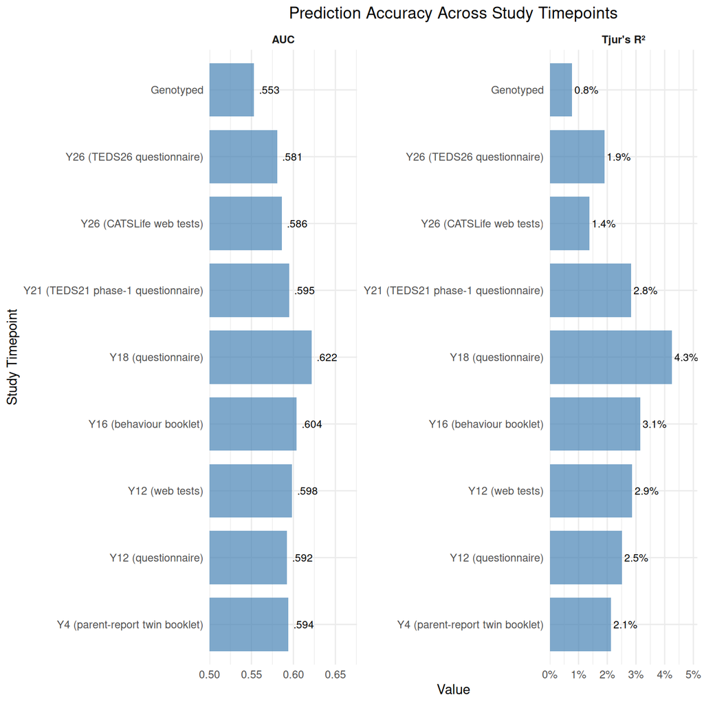

```r
# Extract AUC and pseudo R2 for each model
model_metrics = data.frame(
  outcome = sapply(models, function(x) as.character(x$formula)[2]),
  AUC = sapply(models, calc_auc),
  R2 = sapply(models, function(x) performance::r2(x)$R2)
) %>%
  mutate(outcome = rq1y_twin_labels_clean[match(.$outcome, rq1y_twin1)])

# First, order the outcomes chronologically by extracting year numbers
model_metrics_ordered = model_metrics %>%
  mutate(
    year_num = as.numeric(str_extract(outcome, "\\d+")),
    year_num = if_else(is.na(year_num), Inf, year_num),
    outcome = fct_reorder(outcome, year_num)
  )

plot_data = model_metrics_ordered %>%
  pivot_longer(cols = c(AUC, R2)) %>%
  mutate(
    # Format labels
    label_text = ifelse(name == "R2",
                       paste0(sprintf("%.1f", value * 100), "%"),
                       sprintf("%.3f", value)),
    label_text = ifelse(name == "AUC",
                       gbtoolbox::apa_num(value, n_decimal_places = 3),
                       label_text),
    # Adjust bar start position for AUC (start from 0.5 instead of 0)
    value_start = ifelse(name == "AUC", 0.5, 0),
    value_width = value - value_start
  )

plot_data %>%
  ggplot(aes(y = outcome)) +
  geom_rect(aes(xmin = value_start, xmax = value, ymin = as.numeric(outcome) - 0.4, ymax = as.numeric(outcome) + 0.4),
            fill = "steelblue", alpha = 0.7) +
  geom_text(aes(x = value, label = label_text), hjust = -0.1, size = 3) +
  facet_wrap(~name, scales = "free",
             labeller = labeller(name = c("AUC" = "AUC", "R2" = "Tjur's R²"))) +
  scale_x_continuous(
    labels = function(x) {
      # Check if we're in the R2 facet by looking at the range
      if (max(x, na.rm = TRUE) < 0.2) {  # R2 values are typically small
        paste0(round(x * 100, 1), "%")
      } else {
        sprintf("%.2f", x)
      }
    },
    expand = expansion(mult = c(0, 0.15)),
    limits = function(x) {
      # Set minimum limit to 0.5 for AUC facet (values > 0.2)
      if (max(x, na.rm = TRUE) > 0.2) {
        c(0.5, max(x, na.rm = TRUE) * 1.05)
      } else {
        c(0, max(x, na.rm = TRUE) * 1.05)
      }
    }
  ) +
  labs(
    title = "Prediction Accuracy Across Study Timepoints",
    x = "Value",
    y = "Study Timepoint"
  ) +
  theme_minimal() +
  theme(
    strip.text = element_text(face = "bold"),
    plot.title = element_text(hjust = 0.5)
  )
```

```r
save_plot("2_prediction_accuracy", width = 9, height = 6)
```

📊 View Full Resolution Prediction Accuracy Plot (PNG)

### Full model results

```r
# Extract all coefficients and combine
models_results = do.call(rbind, lapply(1:length(models), function(i) {
  coefs = tidy(models[[i]])
  coefs$outcome = as.character(models[[i]]$formula)[2]
  return(coefs)
}))

models_results %>%
  select(outcome, everything()) %>%
  mutate(
    outcome = var_to_label(outcome) %>% str_remove("data.*"),
    term = df_labels[match(.$term,df_colnames)],
    term   = ifelse(is.na(term), "Intercept", term),
    p_star = as.character(symnum(p.value, cutpoints = c(0, 0.001, 0.01, 0.05, 0.1, 1), symbols = c("***", "**", "*", ".", " ")))
  ) %>%
  knitr::kable(., digits = 3)
```

| outcome | term | estimate | std.error | statistic | p.value | p_star |
| --- | --- | --- | --- | --- | --- | --- |
| Twin booklet | NULL | 0.662 | 0.158 | 4.185 | 0.000 | *** |
| Twin booklet | Maternal Education (formatted as numeric variable) | 0.140 | 0.012 | 11.267 | 0.000 | *** |
| Twin booklet | Vocabulary total score (2 Year), 0-100 | 0.003 | 0.001 | 2.544 | 0.011 | * |
| Twin booklet | Grammar composite score (2 Year), 0-2 | -0.043 | 0.039 | -1.081 | 0.280 |  |
| Twin booklet | Parent-administered Parca mean score (2 Year), standardised | -0.083 | 0.026 | -3.244 | 0.001 | ** |
| Twin booklet | Parent-reported Parca total score (2 Year), 0-26 | 0.017 | 0.008 | 2.135 | 0.033 | * |
| Twin booklet | Conduct SDQ-comparable Behar subscale (2 Year), 0-8 | -0.075 | 0.017 | -4.331 | 0.000 | *** |
| Twin booklet | Emotion SDQ-comparable Behar subscale (2 Year), 0-4 | -0.009 | 0.028 | -0.330 | 0.741 |  |
| Twin booklet | Hyperactivity SDQ-comparable Behar subscale (2 Year), 0-6 | -0.008 | 0.015 | -0.569 | 0.569 |  |
| Twin booklet | Peer SDQ-comparable Behar subscale (2 Year), 0-6 | -0.042 | 0.024 | -1.762 | 0.078 | . |
| Twin booklet | Prosocial SDQ-comparable Behar subscale (2 Year), 0-10 | -0.042 | 0.011 | -3.753 | 0.000 | *** |
| Twin web | NULL | -0.628 | 0.139 | -4.507 | 0.000 | *** |
| Twin web | Maternal Education (formatted as numeric variable) | 0.146 | 0.010 | 14.183 | 0.000 | *** |
| Twin web | Vocabulary total score (2 Year), 0-100 | 0.001 | 0.001 | 0.832 | 0.405 |  |
| Twin web | Grammar composite score (2 Year), 0-2 | 0.020 | 0.035 | 0.572 | 0.567 |  |
| Twin web | Parent-administered Parca mean score (2 Year), standardised | -0.103 | 0.023 | -4.561 | 0.000 | *** |
| Twin web | Parent-reported Parca total score (2 Year), 0-26 | 0.021 | 0.007 | 3.075 | 0.002 | ** |
| Twin web | Conduct SDQ-comparable Behar subscale (2 Year), 0-8 | -0.035 | 0.015 | -2.272 | 0.023 | * |
| Twin web | Emotion SDQ-comparable Behar subscale (2 Year), 0-4 | 0.053 | 0.025 | 2.158 | 0.031 | * |
| Twin web | Hyperactivity SDQ-comparable Behar subscale (2 Year), 0-6 | -0.007 | 0.013 | -0.506 | 0.613 |  |
| Twin web | Peer SDQ-comparable Behar subscale (2 Year), 0-6 | -0.064 | 0.021 | -3.003 | 0.003 | ** |
| Twin web | Prosocial SDQ-comparable Behar subscale (2 Year), 0-10 | -0.020 | 0.010 | -2.073 | 0.038 | * |
| Child questionnaire | NULL | -0.422 | 0.139 | -3.028 | 0.002 | ** |
| Child questionnaire | Maternal Education (formatted as numeric variable) | 0.128 | 0.010 | 12.393 | 0.000 | *** |
| Child questionnaire | Vocabulary total score (2 Year), 0-100 | 0.001 | 0.001 | 1.320 | 0.187 |  |
| Child questionnaire | Grammar composite score (2 Year), 0-2 | 0.013 | 0.035 | 0.386 | 0.699 |  |
| Child questionnaire | Parent-administered Parca mean score (2 Year), standardised | -0.084 | 0.023 | -3.714 | 0.000 | *** |
| Child questionnaire | Parent-reported Parca total score (2 Year), 0-26 | 0.020 | 0.007 | 2.855 | 0.004 | ** |
| Child questionnaire | Conduct SDQ-comparable Behar subscale (2 Year), 0-8 | -0.064 | 0.015 | -4.140 | 0.000 | *** |
| Child questionnaire | Emotion SDQ-comparable Behar subscale (2 Year), 0-4 | 0.055 | 0.025 | 2.255 | 0.024 | * |

[output cut: 69 more lines]

### Variable Importance Calculations

Note: Variable importance is calculated by measuring the change in AUC when each variable is removed from the model.

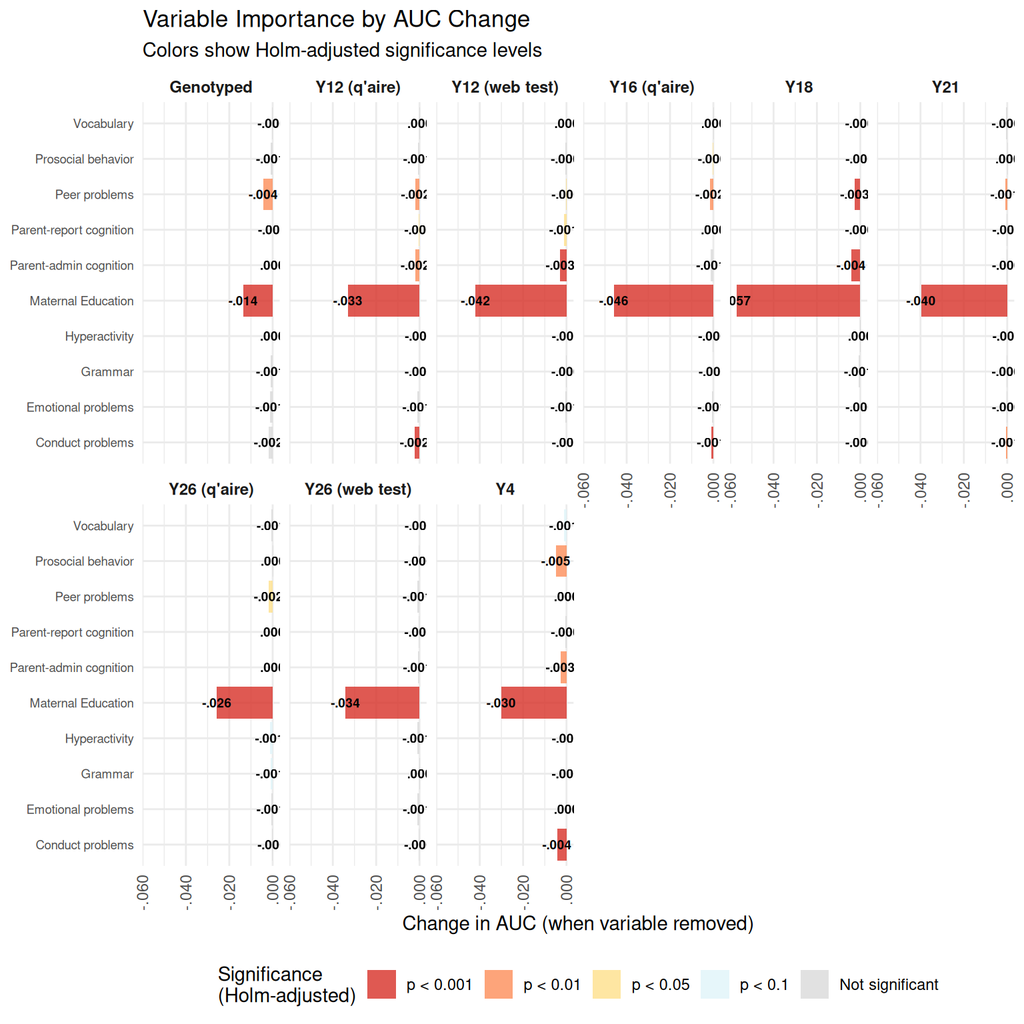

```r
glm_model_comparison_results = lapply(models, glm_model_comparison)

glm_model_comparison_results_df = do.call("rbind.data.frame", glm_model_comparison_results)

# glm_model_comparison_results_df$LRT_p_star = glm_model_comparison_results_df$LRT_p %>%
#   symnum(., cutpoints = c(0, 0.001, 0.01, 0.05, 0.1, 1), symbols = c("***", "**", "*", ".", " "))

# Adjust p-values and add star

glm_model_comparison_results_df = glm_model_comparison_results_df %>%
  filter(Variables_Dropped!="None") %>%
  group_by(outcome) %>%
  mutate(LRT_p = stats::p.adjust(LRT_p, method = "holm")) %>%
  ungroup() %>%
  mutate(
    LRT_p_star = as.character(symnum(LRT_p, cutpoints = c(0, 0.001, 0.01, 0.05, 0.1, 1), symbols = c("***", "**", "*", ".", " ")))
  )

variable_importance_order = glm_model_comparison_results_df %>%
  group_by(Variables_full) %>%
  summarise(mean_score = mean(LRT_p)) %>%
  arrange(mean_score) %>%
  pull(Variables_full)
glm_model_comparison_results_df = glm_model_comparison_results_df %>%
  mutate(
    Variables_full = factor(Variables_full, levels = variable_importance_order)
  )

# Plotting code
glm_model_comparison_results_df %>%
  mutate(
    Variables_full = rq2y_labels_short[match(.$Variables_full, rq2y_labels)],
    outcome_labeled = rq1y_twin_labels_clean_extrashort[match(.$outcome, rq1y_twin1)],
    criterion       = Delta_AUC,
    sig_level = case_when(
      LRT_p < 0.001 ~ "p < 0.001",
      LRT_p < 0.01 ~ "p < 0.01",
      LRT_p < 0.05 ~ "p < 0.05",
      LRT_p < 0.1 ~ "p < 0.1",
      TRUE ~ "Not significant"
    ),
    sig_level = factor(sig_level, levels = c("p < 0.001", "p < 0.01", "p < 0.05", "p < 0.1", "Not significant"))
  ) %>%
  ggplot(aes(y = Variables_full, x = criterion)) +
  geom_col(aes(fill = sig_level), alpha = 0.8) +
  geom_text(aes(label = gsub("0\\.", ".", sprintf("%.3f", criterion))),  # Remove ALL 0. patterns
            size = 2.5, fontface = "bold", color = "black") +
  facet_wrap(~outcome_labeled, scales = "fixed", ncol = 6) +
  scale_x_continuous(labels = function(x) gsub("0\\.", ".", sprintf("%.3f", x))) +  # Remove ALL 0. patterns
  scale_fill_manual(
    values = c("p < 0.001" = "#d73027", "p < 0.01" = "#fc8d59",
               "p < 0.05" = "#fee08b", "p < 0.1" = "#e0f3f8",
               "Not significant" = "#d9d9d9"),
    name = "Significance\n(Holm-adjusted)"
  ) +
  labs(
    x = "Change in AUC (when variable removed)",
    y = NULL,
    title = "Variable Importance by AUC Change",
    subtitle = "Colors show Holm-adjusted significance levels"
  ) +
  theme_minimal() +
  theme(
    axis.text.y = element_text(size = 7),
    axis.text.x = element_text(angle = 90, hjust = 1, vjust = 0.5),
    strip.text = element_text(size = 9, face = "bold"),
    legend.position = "bottom"
  )
```

```r
save_plot("2_rq2_variable_importance", width = 14, height = 7)
```

📊 View Full Resolution Variable Importance Plot (PNG)

## Comparison of maternal education scores

```r
df %>%
  # group_by(zcdata1) %>%
  summarise(
    mean = mean(amohqualn, na.rm = TRUE),
    var  = stats::var(amohqualn1, na.rm = TRUE),
    sd  = stats::sd(amohqualn1, na.rm = TRUE)
    )
```

| mean | var | sd |
| --- | --- | --- |
| 3.72905 | 3.974492 | 1.993613 |

```r
df %>%
  group_by(zcdata1) %>%
  summarise(
    mean = mean(amohqualn, na.rm = TRUE),
    var  = stats::var(amohqualn1, na.rm = TRUE),
    sd   = stats::sd(amohqualn1, na.rm = TRUE)

    )
```

| zcdata1 | mean | var | sd |
| --- | --- | --- | --- |
| 0 | 3.627186 | 3.838022 | 1.959087 |
| 1 | 4.280605 | 4.354096 | 2.086647 |

## Effect of attrition on the variance of maternal education

Unlike the other outcomes, the variance of maternal education increased after attrition in our main analyses. The tables below show that this depends on how maternal education is coded.

In the original 8-level coding used in our main analyses, the higher qualifications are spread over a wide range of codes (A-levels = 4 to postgraduate = 8), far from the most common category (GCSE grades A–C = 3; see the maternal education distribution). Attrition mainly removed families with lower maternal education, so more of the remaining sample fell into these distant upper categories, increasing variance (e.g., by 10% in the Year 26 web test sample). However, this coding does not appear to reflect equal steps: child outcomes were similar for mothers with A-levels, HNC and HND qualifications (see descriptives). When these three categories are merged into a 6-level coding, variance instead decreased slightly in every attritioned sample (by 1–5%), consistent with the other outcomes.

When maternal education is dichotomised into degree vs. no degree, variance increased after attrition (e.g., by 32% in the Year 26 web test sample). This is expected for a binary variable: its variance, *p*(1 − *p*), increases as *p* moves towards .5, and the proportion of mothers with a degree rose from .18 in the full sample to .26 in the Year 26 web test sample.

### Original Coding

```r
entropy = function(x) {
  counts = table(x)
  p = as.numeric(counts) / sum(counts)
  p = p[p > 0]
  -sum(p * log2(p))
}

summary_stats = df %>%
  mutate(mat_edu = amohqualn1) %>%
  select(all_of(rq1y_twin1),mat_edu) %>%
  mutate(fullsample = 1) %>%
  pivot_longer(cols = !mat_edu) %>%
  group_by(name, value) %>%
  summarise(
    mean = mean(mat_edu, na.rm = TRUE),
    var  = sd(mat_edu, na.rm = TRUE)^2,
    entropy = entropy(mat_edu),
    n    = dplyr::n()
  ) %>%
  filter(value == 1)
summary_stats %>%
  mutate(
    name = rq1y_twin_labels_clean_extrashort[match(name, rq1y_twin1)],
    name = case_when(
      is.na(name) ~ "Full Sample",
      .default = name
    )
  ) %>%
  arrange(factor(name, levels = c("Full Sample", rq1y_twin_labels_clean_extrashort))) %>% # longitudinal order, full sample first
  ungroup() %>%
  select(-value) %>%
  gt() %>%
  fmt_number(
    decimals = 3,
    columns = !n
    )
```

| name | mean | var | entropy | n |
| --- | --- | --- | --- | --- |
| Full Sample | 3.729 | 3.974 | 2.588 | 25876 |
| Y4 | 3.996 | 4.195 | 2.600 | 15517 |
| Y12 (web test) | 4.132 | 4.181 | 2.602 | 11474 |
| Y12 (q'aire) | 4.124 | 4.202 | 2.609 | 11432 |
| Y16 (q'aire) | 4.185 | 4.242 | 2.601 | 9876 |
| Y18 | 4.120 | 4.192 | 2.600 | 13736 |
| Y21 | 4.182 | 4.288 | 2.602 | 9730 |
| Y26 (q'aire) | 4.148 | 4.284 | 2.607 | 8456 |
| Y26 (web test) | 4.281 | 4.354 | 2.615 | 4008 |
| Genotyped | 3.941 | 4.090 | 2.595 | 12912 |

### Combining HNC and HND with A-levels

HNC and HND qualifications are vocational and sit ambiguously between A-levels and undergraduate degrees in the original ordinal coding. Here they are collapsed into the A-level category to create a cleaner 6-level ordinal scale. The table shows the mean, variance, and entropy of the recoded maternal education variable for participants at each study timepoint and for the full sample. Higher entropy indicates a more evenly distributed education profile among participants; a decline in entropy relative to the full sample would indicate that attrition is concentrating the sample toward certain education levels.

```r
# table(df$amohqualn1,  df$amohqual)

df3 = df %>%
  mutate(
    mat_edu = case_when(
      .default = amohqualn1,
      amohqualn1 == 5 ~ 4,  # HNC -> A level
      amohqualn1 == 6 ~ 4,  # HND -> A level
      amohqualn1 == 7 ~ 5,  # undergraduate degree
      amohqualn1 == 8 ~ 6   # postgraduate qualification
    )
  ) %>%
  select(all_of(rq1y_twin1),mat_edu)

summary_stats = df3 %>%
  mutate(fullsample = 1) %>%
  pivot_longer(cols = !mat_edu) %>%
  group_by(name, value) %>%
  summarise(
    mean = mean(mat_edu, na.rm = TRUE),
    var  = sd(mat_edu, na.rm = TRUE)^2,
    entropy = entropy(mat_edu),
    n    = dplyr::n()
  ) %>%
  filter(value == 1)
summary_stats %>%
  mutate(
    name = rq1y_twin_labels_clean_extrashort[match(name, rq1y_twin1)],
    name = case_when(
      is.na(name) ~ "Full Sample",
      .default = name
    )
  ) %>%
  arrange(factor(name, levels = c("Full Sample", rq1y_twin_labels_clean_extrashort))) %>% # longitudinal order, full sample first
  ungroup() %>%
  select(-value) %>%
  gt() %>%
  fmt_number(
    decimals = 3,
    columns = !n
    )
```

| name | mean | var | entropy | n |
| --- | --- | --- | --- | --- |
| Full Sample | 3.270 | 1.672 | 2.341 | 25876 |
| Y4 | 3.451 | 1.657 | 2.336 | 15517 |
| Y12 (web test) | 3.542 | 1.594 | 2.316 | 11474 |
| Y12 (q'aire) | 3.535 | 1.610 | 2.325 | 11432 |
| Y16 (q'aire) | 3.579 | 1.609 | 2.323 | 9876 |
| Y18 | 3.535 | 1.605 | 2.320 | 13736 |
| Y21 | 3.576 | 1.632 | 2.328 | 9730 |
| Y26 (q'aire) | 3.554 | 1.649 | 2.337 | 8456 |
| Y26 (web test) | 3.645 | 1.645 | 2.334 | 4008 |
| Genotyped | 3.416 | 1.628 | 2.329 | 12912 |

```r
table(df$amohqualn1, df3$mat_edu)
```

```
       1    2    3    4    5    6
  1 2396    0    0    0    0    0
  2    0 3978    0    0    0    0
  3    0    0 9508    0    0    0
  4    0    0    0 3386    0    0
  5    0    0    0  712    0    0
  6    0    0    0  968    0    0
  7    0    0    0    0 2968    0
  8    0    0    0    0    0 1550
```

### Dichotomising education into degree vs. no degree

Here maternal education is reduced to a binary variable: whether or not the mother holds an undergraduate or postgraduate degree. This is a common simplification in the literature and avoids assumptions about the spacing of the ordinal scale. The table shows the proportion of mothers with a degree (mean), variance, and entropy among participants at each timepoint and in the full sample. A rising proportion of degree-educated mothers across timepoints would indicate that attrition disproportionately removes families from lower education backgrounds.

```r
df4 = df %>%
  mutate(
    mat_edu_degree = case_when(
      amohqualn1 >= 7 ~ 1L,  # undergraduate degree or above
      amohqualn1 <  7 ~ 0L,
      .default = NA_integer_
    )
  ) %>%
  select(all_of(rq1y_twin1), mat_edu_degree)

summary_stats_degree = df4 %>%
  mutate(fullsample = 1) %>%
  pivot_longer(cols = !mat_edu_degree) %>%
  group_by(name, value) %>%
  summarise(
    mean    = mean(mat_edu_degree, na.rm = TRUE),
    var     = sd(mat_edu_degree, na.rm = TRUE)^2,
    entropy = entropy(mat_edu_degree),
    n       = dplyr::n()
  ) %>%
  filter(value == 1)
summary_stats_degree %>%
  mutate(
    name = rq1y_twin_labels_clean_extrashort[match(name, rq1y_twin1)],
    name = case_when(
      is.na(name) ~ "Full Sample",
      .default = name
    )
  ) %>%
  arrange(factor(name, levels = c("Full Sample", rq1y_twin_labels_clean_extrashort))) %>% # longitudinal order, full sample first
  ungroup() %>%
  select(-value) %>%
  gt() %>%
  fmt_number(
    decimals = 3,
    columns = !n
  )
```

| name | mean | var | entropy | n |
| --- | --- | --- | --- | --- |
| Full Sample | 0.177 | 0.146 | 0.674 | 25876 |
| Y4 | 0.217 | 0.170 | 0.755 | 15517 |
| Y12 (web test) | 0.233 | 0.179 | 0.784 | 11474 |
| Y12 (q'aire) | 0.233 | 0.179 | 0.784 | 11432 |
| Y16 (q'aire) | 0.245 | 0.185 | 0.804 | 9876 |
| Y18 | 0.232 | 0.178 | 0.782 | 13736 |
| Y21 | 0.246 | 0.186 | 0.806 | 9730 |
| Y26 (q'aire) | 0.242 | 0.183 | 0.798 | 8456 |
| Y26 (web test) | 0.261 | 0.193 | 0.829 | 4008 |
| Genotyped | 0.206 | 0.164 | 0.735 | 12912 |

```r
table(df$amohqualn1, df4$mat_edu_degree)
```

```
       0    1
  1 2396    0
  2 3978    0
  3 9508    0
  4 3386    0
  5  712    0
  6  968    0
  7    0 2968
  8    0 1550
```

## Distribution of maternal education: full sample vs. Y26 Webtest participants

The plot below compares the distribution of maternal education (`amohqual`) between the full TEDS sample and those who participated at the Y26 Webtest (`zcdata1 == 1`). Bars show the proportion of mothers at each education level within each group.

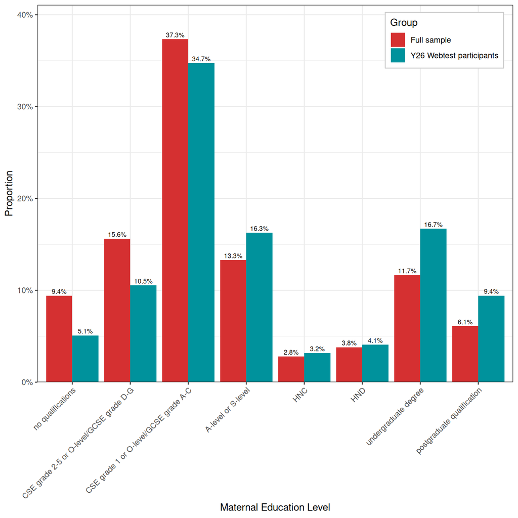

```r
df %>%
  # filter(twin==1) %>%
  select(zcdata1, amohqual) %>%
  mutate(fullsample = 1) %>%
  pivot_longer(cols = c(fullsample, zcdata1), names_to = "group", values_to = "participated") %>%
  filter(participated == 1, !is.na(amohqual)) %>%
  mutate(group = if_else(group == "fullsample", "Full sample", "Y26 Webtest participants")) %>%
  group_by(group, amohqual) %>%
  summarise(n = dplyr::n(), .groups = "drop") %>%
  group_by(group) %>%
  mutate(prop = n / sum(n)) %>%
  ungroup() %>%
  mutate(amohqual = factor(amohqual, levels = levels(df$amohqual))) %>%
  ggplot(aes(x = amohqual, y = prop, fill = group)) +
  geom_col(position = "dodge") +
  geom_text(
    aes(label = scales::percent(prop, accuracy = 0.1)),
    position = position_dodge(width = 0.9),
    vjust = -0.4,
    size = 2.5
  ) +
  scale_y_continuous(
    labels = scales::percent_format(accuracy = 1),
    expand = expansion(mult = c(0, 0.1))
  ) +
  scale_fill_manual(values = c("Full sample" = "#d53031", "Y26 Webtest participants" = "#00929c")) +
  theme_bw() +
  theme(
    axis.text.x = element_text(angle = 45, hjust = 1),
    legend.position = "inside",
    legend.position.inside = c(0.98, 0.98),
    legend.justification = c("right", "top"),
    legend.background = element_rect(colour = "grey80")
  ) +
  labs(
    x = "Maternal Education Level",
    y = "Proportion",
    fill = "Group"
  )
```